# GGM Simulation. Effect of prior slab variance

```r
library(modelSelection)
library(mvtnorm)
library(tidyverse)
library(lamW)      # Lambert's W_q function
set.seed(20260710) # for reproducibility
save2pdf <- TRUE
nsims <- 20 # number of simulations
nseq <- c(100, 500)    # sample size
```

# Set default prior parameters

We consider a discrete spike-and-slab prior on the precision matrix, with a Beta-Binomial(1,2) prior. That is, the edge inclusion indicators are $Z_{ij} \sim \mbox{Bern}(\eta)$ with $\eta \sim \mbox{Beta}(1,2)$. This is a minimally informative prior that slightly favors smaller model sizes, but still places significant prior mass on dense models (many edges). The prior on diagonal elements is $\theta_{ii} \sim \mbox{Exp}(\lambda/2)$, with expectation $\mu= 2/\lambda$, and the prior on off-diagonal elements is $\theta_{ij} \sim N(0, \sigma^2)$. A natural default is $\sigma^2 =1$. If all the columns in the observed dataset are standardized to zero sample mean and unit sample variance, this default is related to Zellner’s unit information prior in regression. We consider three settings:

1. A default $\lambda=1$, and $\sigma^2=1$.
2. A default $\lambda=1$, with $\sigma^2$ specified such that $P(\Theta \succ 0) = 0.95$. This guarantees that the total variation distance between the priors before and after positive-definiteness truncation is small, and hence that the prior is interpretable.
3. Set $\lambda$ such that $P(\Theta_{ii} \succ 0 \mid Z) \geq 1 - \alpha$ for every edge configuration $Z$ and taking $\alpha=0.1$, and $\sigma^2=1$.

```r
edge_prob_succ= 1 # prior number of successes
edge_prob_fail= 2 # prior number of failures
mu = 9.5       # mean of off-diagonal
lambda= 2/mu
pexp(1, rate=lambda/2, lower.tail=FALSE) #equals 0.9
```

```
## [1] 0.9000876
```

We next obtain the value of $\lambda$ for Setting 3.

```r
sd.slab <- 1
alpha <- 0.1
kseq <- c(50, 100)
names(kseq) <- paste('k=', kseq, sep='')
x <- - alpha^2 /(32 * exp(2) * kseq^2)
l <- lambertWm1(x) # q = -1 branch of Lambert's W_q function
mu <- (2 * sd.slab * kseq^(3/2) / alpha) * sqrt(-l)
lambda2 <- 2/mu
names(lambda2) <- names(kseq)
lambda2
```

```
##         k=50        k=100
## 6.181495e-05 2.113364e-05
```

Finally, for setting 2, given the prior edge inclusion probability $\eta$ and $\lambda$, function `randompdmatrix_setpars` finds the value of $\sigma^2$ such that $P(\Theta \succ 0)=0.95$. This is done via Monte Carlo, that is sampling from the prior and finding $\sigma$ such that $P(\Theta \succ 0) = 0.95$.

```r
var.slab.setting2 <- double(length(kseq))
names(var.slab.setting2) <- paste('k=', kseq, sep='')
for (i in 1:length(kseq)) {
  var.slab.setting2[i] <- modelSelection:::randompdmatrix_setpars(p=kseq[i], edge_prob_priorsucc=edge_prob_succ, edge_prob_priorfail= edge_prob_fail, diag_distrib='Exp', diag_mean=2, method='MC')$offdiag_variance
}
```

We store the prior parameter values obtained for each setting and $k = \mbox{dim}(\Theta)$.

```r
priorpars <- expand.grid(setting=c('Setting 1', 'Setting 2', 'Setting 3'), k=kseq)
priorpars$edge_prob_succ <- edge_prob_succ
priorpars$edge_prob_fail <- edge_prob_fail
priorpars$lambda <- priorpars$var.slab <- NA
for (i in 1:nrow(priorpars)) {
  if (priorpars$setting[i] == 'Setting 1') {
    priorpars$lambda[i] <- 1
    priorpars$var.slab[i] <- 1
  } else if (priorpars$setting[i] == 'Setting 2') {
    priorpars$lambda[i] <- 1
    priorpars$var.slab[i] <- var.slab.setting2[paste('k=', priorpars$k[i], sep='')]
  } else if (priorpars$setting[i] == 'Setting 3') {
    priorpars$lambda[i] <- lambda2[paste('k=', priorpars$k[i], sep='')]
    priorpars$var.slab[i] <- 1
  }
}
priorpars
```

```
##     setting   k edge_prob_succ edge_prob_fail     var.slab       lambda
## 1 Setting 1  50              1              2 1.000000e+00 1.000000e+00
## 2 Setting 2  50              1              2 1.757805e-05 1.000000e+00
## 3 Setting 3  50              1              2 1.000000e+00 6.181495e-05
## 4 Setting 1 100              1              2 1.000000e+00 1.000000e+00
## 5 Setting 2 100              1              2 1.445164e-05 1.000000e+00
## 6 Setting 3 100              1              2 1.000000e+00 2.113364e-05
```

# Function to run simulations

We create a function that simulates data from a multivariate Gaussian, fits a Bayesian Gaussian graphical model model under a discrete spike-and-slab prior, and record the mean squared estimation error, the average estimate of each $\theta_{ij}$ entry, and the average posterior probability $P(\theta_{ij} \neq 0 \mid y)$.

```r
run_simulations <- function(n, nsims, Theta, Sigma=solve(Theta), priorCoef, priorDiag, priorModel, scale=TRUE) {
  ans = vector("list", nsims)
  for (i in 1:nsims) {
    set.seed(i)  #for reproducibility

    ansi = vector("list", length(n))
    for (j in 1:length(n)) {

      # Simulate data
      samplesize <- n[j]
      y = rmvnorm(samplesize, sigma= Sigma)
      sy = apply(y, 2, 'sd')

      # Fit models
      fit = modelSelectionGGM(y=y, priorCoef=priorCoef, priorDiag=priorDiag, priorModel=priorModel, center=scale, scale=scale, verbose=FALSE)

      # Extract BMA parameter estimates and posterior edge inclusion probabilities
      b= data.frame(coef(fit)) |>
        select(row, column, estimate, margpp)

      # Convert to original scale
      scaling = 1 / (sy[b$row] * sy[b$column])
      b = transform(b, estimate= estimate * scaling)

      # Add data-generating truth
      if (i==1) {
        truth = double(nrow(b))
        for (l in 1:nrow(b)) truth[l] = Theta[b$row[l], b$column[l]]
      }
      b$truth = truth

      # Record MSE, average posterior inclusion probability and average point estimate
      ansi[[j]] = group_by(b, truth) |>
                 summarize(mse = mean((truth - estimate)^2), pp = mean(margpp), mean_estimate = mean(estimate), count = n()) |>
                 cbind(simid = i, n = samplesize)

      cat('.')

    }

    ans[[i]] <- do.call(rbind, ansi)
  }
  return(ans)
}
```

# Banded diagonal

## Run simulations

```r
sims1 <- sims2 <- sims3 <- vector("list", length(kseq))
names(sims1) <- names(sims2) <- names(sims3) <- names(kseq)
diagvals <- vector("list", length(kseq))
for (i in 1:length(kseq)) {
  ksel <- kseq[i]  # number of variables
  cat("Simulations for k =", ksel)

  # Data-generating precision matrix
  Theta= diag(ksel)
  Theta[abs(col(Theta) - row(Theta)) == 1] <- 0.5
  Theta[abs(col(Theta) - row(Theta)) == 2] <- 0.25
  Sigma = solve(Theta)
  diagvals[[i]] <- unique(diag(Theta))

  # Set prior distribution under each setting
  pars_sel <- filter(priorpars, setting == "Setting 1", k == ksel)
  priorModel <- modelbbprior(pars_sel$edge_prob_succ, pars_sel$edge_prob_fail)
  priorDiag <- exponentialprior(lambda = pars_sel$lambda)
  priorCoef <- normalidprior(pars_sel$var.slab)
  sims1[[i]] <- run_simulations(n=nseq, nsims=nsims, Theta=Theta, Sigma=solve(Theta), priorCoef=priorCoef, priorDiag=priorDiag, priorModel=priorModel)

  pars_sel <- filter(priorpars, setting == "Setting 2", k == ksel)
  priorModel <- modelbbprior(pars_sel$edge_prob_succ, pars_sel$edge_prob_fail)
  priorDiag <- exponentialprior(lambda = pars_sel$lambda)
  priorCoef <- normalidprior(pars_sel$var.slab)
  sims2[[i]] <- run_simulations(n=nseq, nsims=nsims, Theta=Theta, Sigma=solve(Theta), priorCoef=priorCoef, priorDiag=priorDiag, priorModel=priorModel)

  pars_sel <- filter(priorpars, setting == "Setting 3", k == ksel)
  priorModel <- modelbbprior(pars_sel$edge_prob_succ, pars_sel$edge_prob_fail)
  priorDiag <- exponentialprior(lambda = pars_sel$lambda)
  priorCoef <- normalidprior(pars_sel$var.slab)
  sims3[[i]] <- run_simulations(n=nseq, nsims=nsims, Theta=Theta, Sigma=solve(Theta), priorCoef=priorCoef, priorDiag=priorDiag, priorModel=priorModel)

  cat("\n")
}
```

```
## Simulations for k = 50........................................................................................................................
## Simulations for k = 100........................................................................................................................
```

```r
diagvals <- unique(unlist(diagvals))
```

We summarize the results across all simulations. For each prior parameter setting and $k= \mbox{dim}(\Theta)$, and each value of the data-generating $\Theta_{ij}$, we report the mean squared estimation error in the Bayesian model averaging estimate $E(\Theta_{ij} \mid y)$, the average marginal posterior edge inclusion probability $P(\Theta_{ij} \neq 0 \mid y)$, and the average BMA estimate.

```r
summarize_simulations <- function(kseq, sims1, sims2, sims3) {

  sim_summary <- vector("list", length(kseq))
  names(sim_summary) <- names(kseq)

  for (i in 1:length(kseq)) {

    summary1 = do.call(rbind, sims1[[i]]) |>
      data.frame() |>
      group_by(n, truth) |>
      summarize(across(mse:count, mean), .groups="drop") |>
      transform(k = kseq[i], Setting = "Setting 1")

    summary2 = do.call(rbind, sims2[[i]]) |>
      data.frame() |>
      group_by(n, truth) |>
      summarize(across(mse:count, mean), .groups="drop") |>
      transform(k = kseq[i], Setting = "Setting 2")

    summary3 = do.call(rbind, sims3[[i]]) |>
      data.frame() |>
      group_by(n, truth) |>
      summarize(across(mse:count, mean), .groups="drop") |>
      transform(k = kseq[i], Setting = "Setting 3")

    sim_summary[[i]] <- rbind(summary1, summary2, summary3)

  }

  sim_summary <- do.call(rbind, sim_summary) |>
    transform(root_mse = round(sqrt(mse),3), pp = round(pp,3), mean_estimate = round(mean_estimate, 4)) |>
    select(-mse) |>
    select(Setting, k, root_mse, everything())

  rownames(sim_summary) <- NULL

  return(sim_summary)
}
```

```r
sim_summary <- summarize_simulations(kseq=kseq, sims1=sims1, sims2=sims2, sims3=sims3)
sim_summary
```

```
##      Setting   k root_mse   n truth    pp mean_estimate count
## 1  Setting 1  50    0.015 100  0.00 0.026       -0.0008  1128
## 2  Setting 1  50    0.159 100  0.25 0.526        0.1467    48
## 3  Setting 1  50    0.165 100  0.50 0.934        0.3989    49
## 4  Setting 1  50    0.144 100  1.00 1.000        0.9876    50
## 5  Setting 1  50    0.003 500  0.00 0.012        0.0000  1128
## 6  Setting 1  50    0.035 500  0.25 0.999        0.2460    48
## 7  Setting 1  50    0.044 500  0.50 1.000        0.4934    49
## 8  Setting 1  50    0.061 500  1.00 1.000        1.0045    50
## 9  Setting 2  50    0.000 100  0.00 0.106        0.0000  1128
## 10 Setting 2  50    0.250 100  0.25 0.106        0.0000    48
## 11 Setting 2  50    0.500 100  0.50 0.107        0.0000    49
## 12 Setting 2  50    0.438 100  1.00 1.000        0.5722    50
## 13 Setting 2  50    0.000 500  0.00 0.604        0.0000  1128
## 14 Setting 2  50    0.250 500  0.25 0.611        0.0004    48
```

[output cut: 34 more lines]

## Plots

We first display the root mean square error, and subsequently the average posterior inclusion probability.

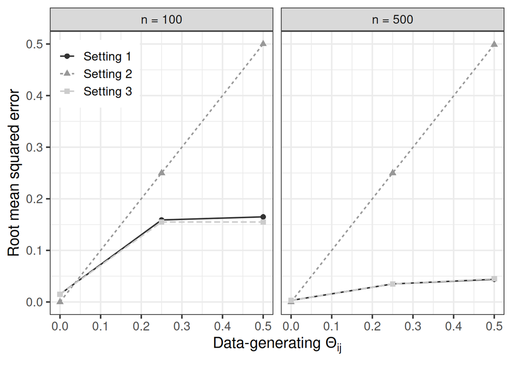

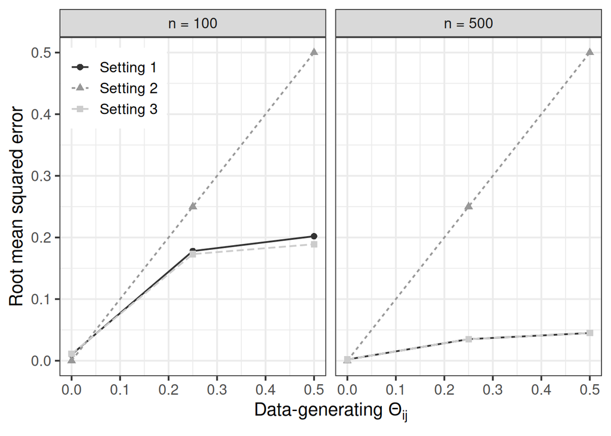

```r
for (i in 1:length(kseq)) {

  myplot <- filter(sim_summary, !(truth %in% diagvals), k==kseq[i]) |>
  ggplot(aes(x=truth, y=root_mse, col=Setting, lty=Setting, pch=Setting)) +
    geom_line() +
    geom_point() +
    facet_wrap(~ n, labeller = labeller(n = function(x) paste0("n = ", x))) +
    theme_bw(base_size = 15) +
    theme(legend.position = c(0.1, 0.85), legend.title=element_blank()) +
    scale_color_grey() +
    xlab(expression("Data-generating " * Theta[ij])) +
    ylab("Root mean squared error")
  print(myplot)

  fname <- paste0("sim_priorsettings_banded_rootmse_nodiag_k", kseq[i], ".pdf")
  if (save2pdf) ggsave(fname, plot = myplot)
}
```

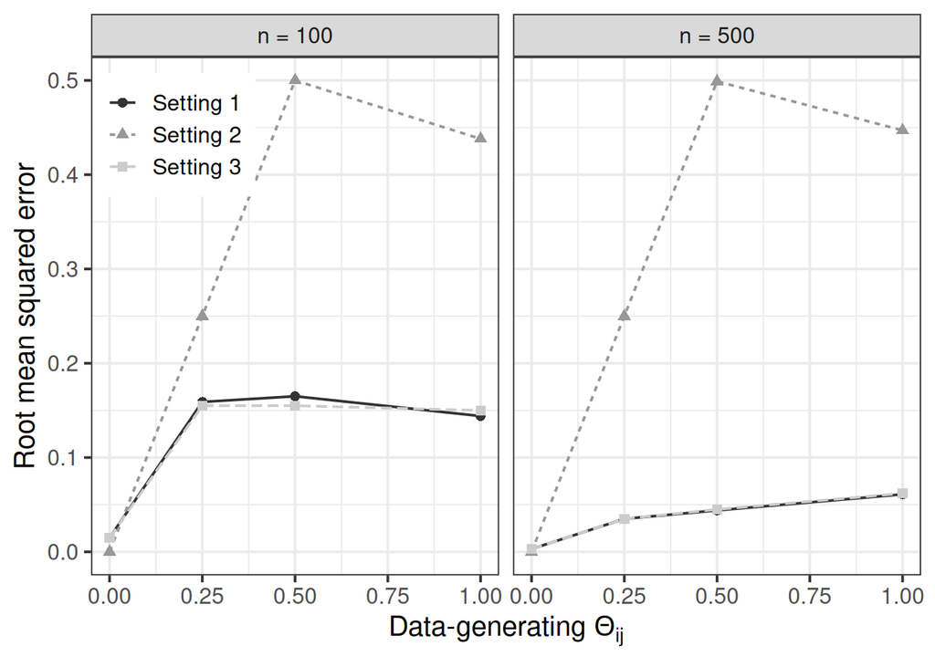

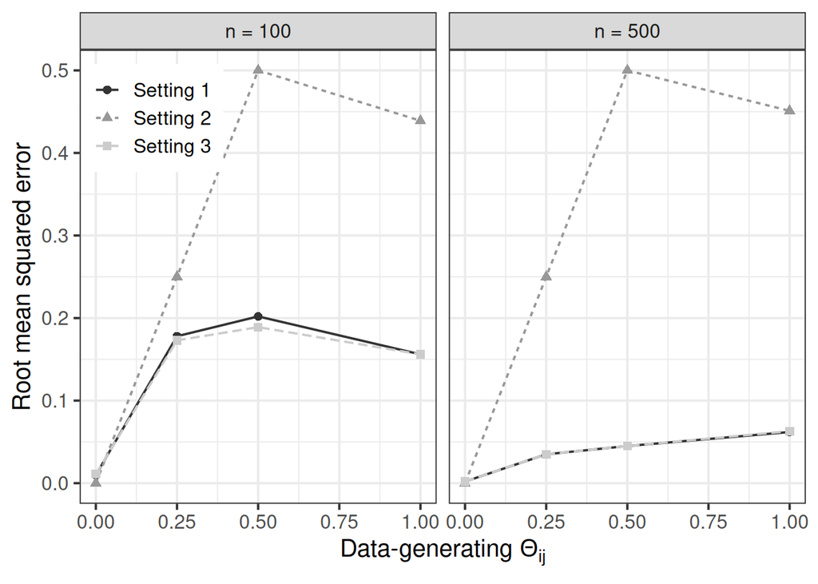

```r
for (i in 1:length(kseq)) {

  myplot <- filter(sim_summary, k==kseq[i]) |>
  ggplot(aes(x=truth, y=root_mse, col=Setting, lty=Setting, pch=Setting)) +
    geom_line() +
    geom_point() +
    facet_wrap(~ n, labeller = labeller(n = function(x) paste0("n = ", x))) +
    theme_bw(base_size = 15) +
    theme(legend.position = c(0.1, 0.85), legend.title=element_blank()) +
    scale_color_grey() +
    xlab(expression("Data-generating " * Theta[ij])) +
    ylab("Root mean squared error")
  print(myplot)

  fname <- paste0("sim_priorsettings_banded_rootmse_k", kseq[i], ".pdf")
  if (save2pdf) ggsave(fname, plot=myplot)
}
```

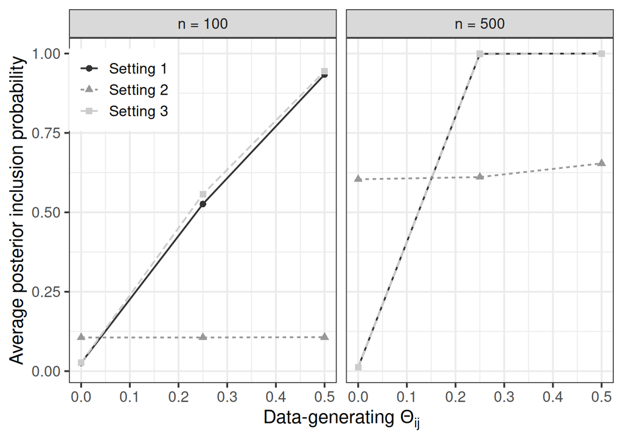

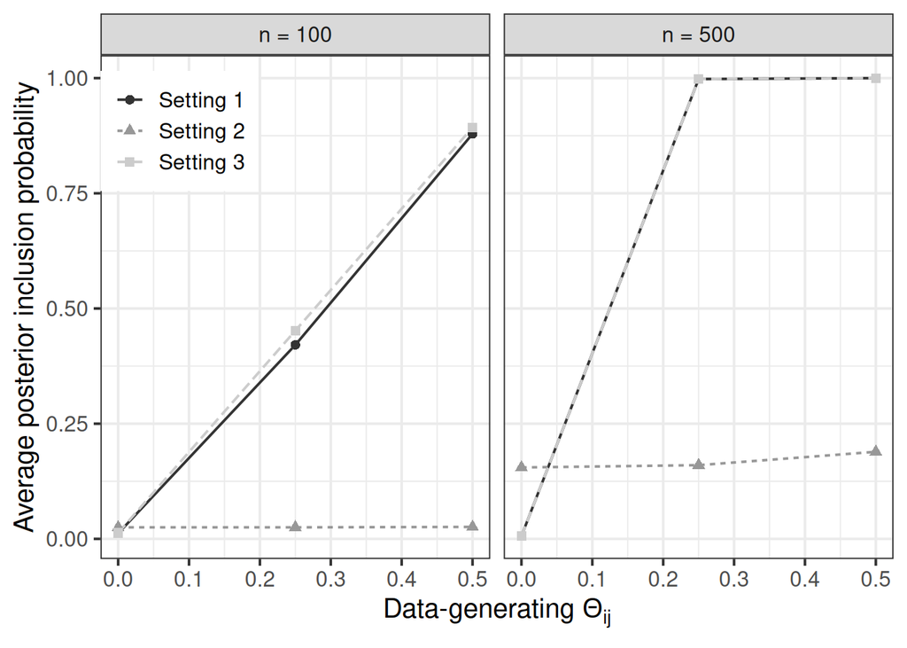

```r
for (i in 1:length(kseq)) {

  myplot <- filter(sim_summary, !(truth %in% diagvals), k==kseq[i]) |>
  ggplot(aes(x=truth, y=pp, col=Setting, lty=Setting, pch=Setting)) +
    geom_line() +
    geom_point() +
    facet_wrap(~ n, labeller = labeller(n = function(x) paste0("n = ", x))) +
    theme_bw(base_size = 15) +
    theme(legend.position = c(0.1, 0.85), legend.title=element_blank()) +
    scale_color_grey() +
    xlab(expression("Data-generating " * Theta[ij])) +
    ylab("Average posterior inclusion probability")
  print(myplot)

  fname <- paste0("sim_priorsettings_banded_pp_k", kseq[i], ".pdf")
  if (save2pdf) ggsave(fname, plot = myplot)
}
```

# Star graph

## Run simulations

```r
sims1 <- sims2 <- sims3 <- vector("list", length(kseq))
names(sims1) <- names(sims2) <- names(sims3) <- names(kseq)
diagvals <- vector("list", length(kseq))
for (i in 1:length(kseq)) {
  ksel <- kseq[i]  # number of variables
  cat("Simulations for k =", ksel)

  # Data-generating precision matrix
  Theta <- diag(ksel)
  Theta[1, 2:ksel] <- 0.5
  Theta[2:ksel, 1] <- 0.5
  diag(Theta) <- rowSums(abs(Theta)) + 0.01
  Sigma = solve(Theta)
  diagvals[[i]] <- unique(diag(Theta))

  # Set prior distribution under each setting
  pars_sel <- filter(priorpars, setting == "Setting 1", k == ksel)
  priorModel <- modelbbprior(pars_sel$edge_prob_succ, pars_sel$edge_prob_fail)
  priorDiag <- exponentialprior(lambda = pars_sel$lambda)
  priorCoef <- normalidprior(pars_sel$var.slab)
  sims1[[i]] <- run_simulations(n=nseq, nsims=nsims, Theta=Theta, Sigma=solve(Theta), priorCoef=priorCoef, priorDiag=priorDiag, priorModel=priorModel, scale=FALSE)

  pars_sel <- filter(priorpars, setting == "Setting 2", k == ksel)
  priorModel <- modelbbprior(pars_sel$edge_prob_succ, pars_sel$edge_prob_fail)
  priorDiag <- exponentialprior(lambda = pars_sel$lambda)
  priorCoef <- normalidprior(pars_sel$var.slab)
  sims2[[i]] <- run_simulations(n=nseq, nsims=nsims, Theta=Theta, Sigma=solve(Theta), priorCoef=priorCoef, priorDiag=priorDiag, priorModel=priorModel, scale=FALSE)

  pars_sel <- filter(priorpars, setting == "Setting 3", k == ksel)
  priorModel <- modelbbprior(pars_sel$edge_prob_succ, pars_sel$edge_prob_fail)
  priorDiag <- exponentialprior(lambda = pars_sel$lambda)
  priorCoef <- normalidprior(pars_sel$var.slab)
  sims3[[i]] <- run_simulations(n=nseq, nsims=nsims, Theta=Theta, Sigma=solve(Theta), priorCoef=priorCoef, priorDiag=priorDiag, priorModel=priorModel, scale=FALSE)

  cat("\n")
}
```

```
## Simulations for k = 50........................................................................................................................
## Simulations for k = 100........................................................................................................................
```

```r
diagvals <- unique(unlist(diagvals))
```

We summarize the results across all simulations. For each prior parameter setting and $k= \mbox{dim}(\Theta)$, and each value of the data-generating $\Theta_{ij}$, we report the mean squared estimation error in the Bayesian model averaging estimate $E(\Theta_{ij} \mid y)$, the average marginal posterior edge inclusion probability $P(\Theta_{ij} \neq 0 \mid y)$, and the average BMA estimate.

```r
sim_summary <- summarize_simulations(kseq=kseq, sims1=sims1, sims2=sims2, sims3=sims3)
sim_summary
```

```
##      Setting   k root_mse   n truth    pp mean_estimate count
## 1  Setting 1  50    0.008 100  0.00 0.001        0.0000  1176
## 2  Setting 1  50    0.493 100  0.50 0.002        0.0085    49
## 3  Setting 1  50    1.116 100  1.51 1.000        2.3741    49
## 4  Setting 1  50  250.115 100 25.51 1.000      262.4866     1
## 5  Setting 1  50    0.003 500  0.00 0.001       -0.0001  1176
## 6  Setting 1  50    0.746 500  0.50 0.058        0.2365    49
## 7  Setting 1  50    0.792 500  1.51 1.000        2.2500    49
## 8  Setting 1  50  309.911 500 25.51 1.000      332.3071     1
## 9  Setting 2  50    0.000 100  0.00 0.096        0.0000  1176
## 10 Setting 2  50    0.500 100  0.50 0.095        0.0000    49
## 11 Setting 2  50    1.108 100  1.51 1.000        2.3665    49
## 12 Setting 2  50  249.132 100 25.51 1.000      261.4069     1
## 13 Setting 2  50    0.000 500  0.00 0.100        0.0000  1176
## 14 Setting 2  50    0.500 500  0.50 0.101        0.0001    49
```

[output cut: 34 more lines]

## Plots

We first display the root mean square error, and subsequently the average posterior inclusion probability.

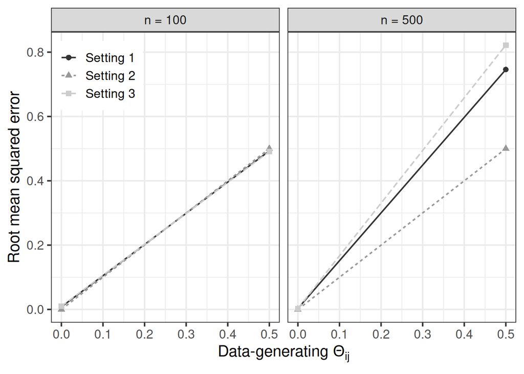

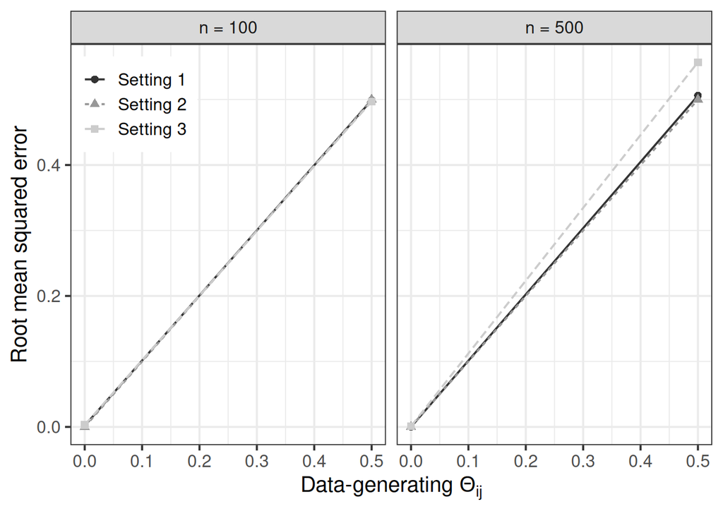

```r
for (i in 1:length(kseq)) {

  myplot <- filter(sim_summary, !(truth %in% diagvals), k==kseq[i]) |>
  ggplot(aes(x=truth, y=root_mse, col=Setting, lty=Setting, pch=Setting)) +
    geom_line() +
    geom_point() +
    facet_wrap(~ n, labeller = labeller(n = function(x) paste0("n = ", x))) +
    theme_bw(base_size = 15) +
    theme(legend.position = c(0.1, 0.85), legend.title=element_blank()) +
    scale_color_grey() +
    xlab(expression("Data-generating " * Theta[ij])) +
    ylab("Root mean squared error")
  print(myplot)

  fname <- paste0("sim_priorsettings_star_rootmse_nodiag_k", kseq[i], ".pdf")
  if (save2pdf) ggsave(fname, plot = myplot)
}
```

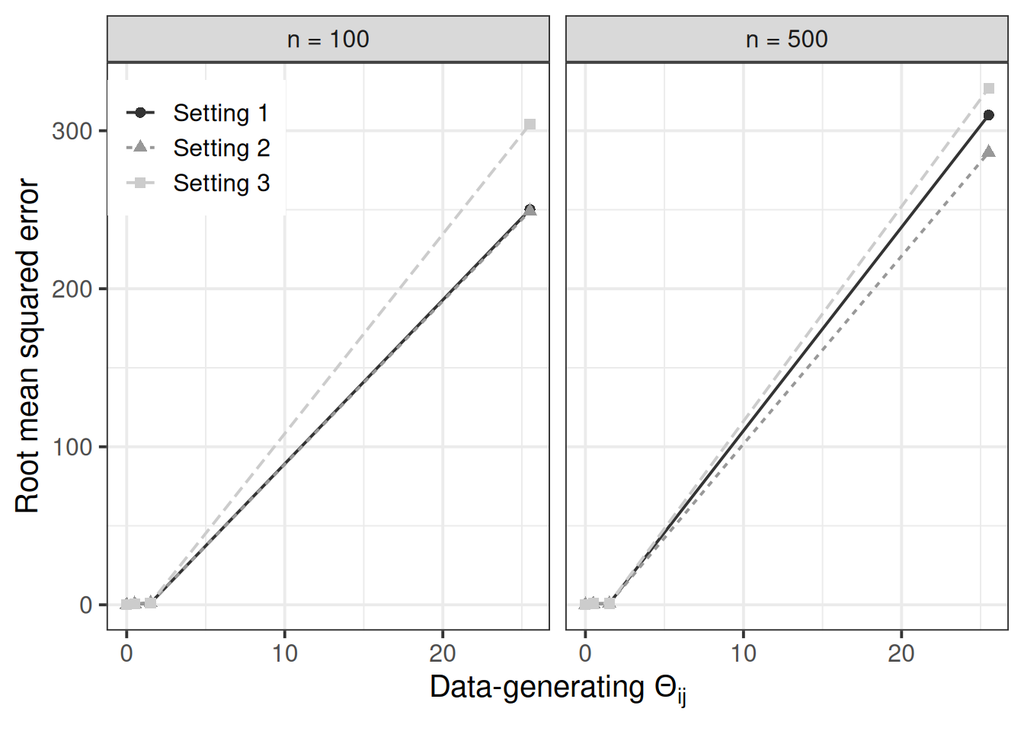

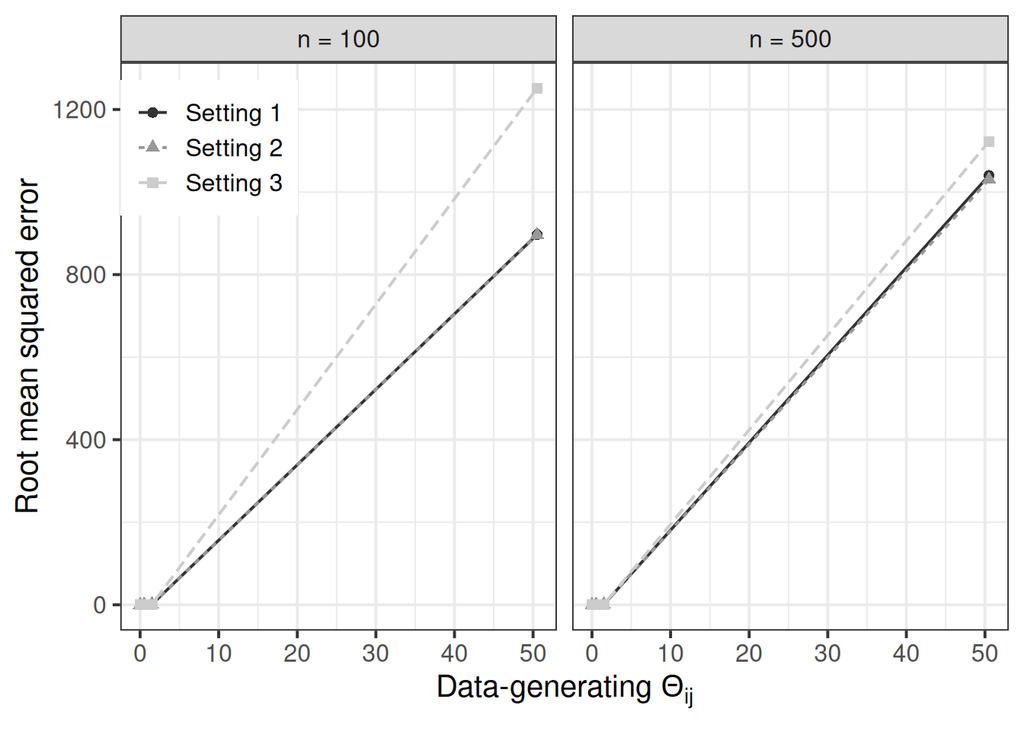

```r
for (i in 1:length(kseq)) {

  myplot <- filter(sim_summary, k==kseq[i]) |>
  ggplot(aes(x=truth, y=root_mse, col=Setting, lty=Setting, pch=Setting)) +
    geom_line() +
    geom_point() +
    facet_wrap(~ n, labeller = labeller(n = function(x) paste0("n = ", x))) +
    theme_bw(base_size = 15) +
    theme(legend.position = c(0.1, 0.85), legend.title=element_blank()) +
    scale_color_grey() +
    xlab(expression("Data-generating " * Theta[ij])) +
    ylab("Root mean squared error")
  print(myplot)

  fname <- paste0("sim_priorsettings_star_rootmse_k", kseq[i], ".pdf")
  if (save2pdf) ggsave(fname, plot = myplot)
}
```

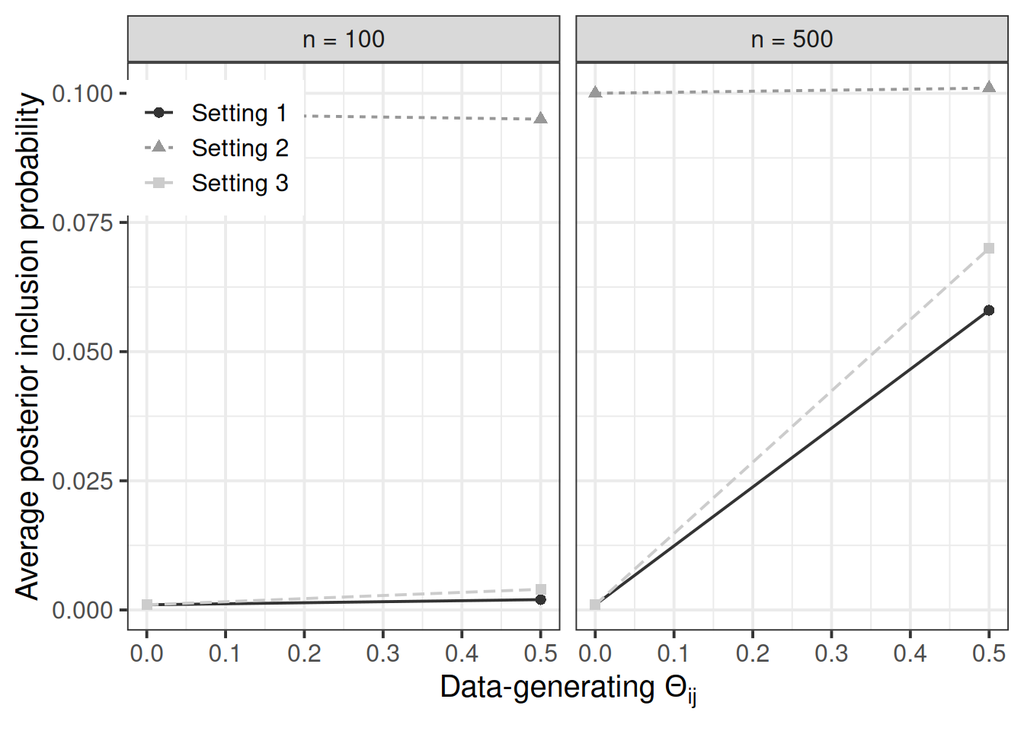

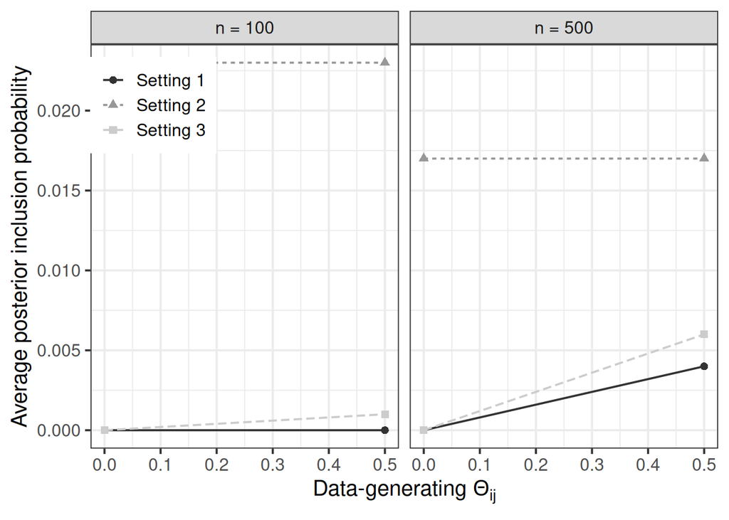

```r
for (i in 1:length(kseq)) {

  myplot <- filter(sim_summary, !(truth %in% diagvals), k==kseq[i]) |>
  ggplot(aes(x=truth, y=pp, col=Setting, lty=Setting, pch=Setting)) +
    geom_line() +
    geom_point() +
    facet_wrap(~ n, labeller = labeller(n = function(x) paste0("n = ", x))) +
    theme_bw(base_size = 15) +
    theme(legend.position = c(0.1, 0.85), legend.title=element_blank()) +
    scale_color_grey() +
    xlab(expression("Data-generating " * Theta[ij])) +
    ylab("Average posterior inclusion probability")
  print(myplot)

  fname <- paste0("sim_priorsettings_star_pp_k", kseq[i], ".pdf")
  if (save2pdf) ggsave(fname, plot = myplot)
}
```

# Erdos-Renyi graph

## Run simulations

```r
sims1 <- sims2 <- sims3 <- vector("list", length(kseq))
names(sims1) <- names(sims2) <- names(sims3) <- names(kseq)
diagvals <- vector("list", length(kseq))
for (i in 1:length(kseq)) {
  ksel <- kseq[i]  # number of variables
  cat("Simulations for k =", ksel)

  # Data-generating precision matrix
  y <- matrix(nrow=0, ncol=ksel)
  sample <- modelSelectionGGM(y, priorCoef=normalidprior(1), priorModel=modelbinomprior(0.1), priorDiag=exponentialprior(1), niter=500, verbose=FALSE)
  Theta <- diag(ksel)
  thetavals <- sample$postSample[nrow(sample$postSample),]
  for (j in 1:ncol(sample$indexes)) {
    Theta[sample$indexes['row',j], sample$indexes['column',j]] <- thetavals[j]
    Theta[sample$indexes['column',j], sample$indexes['row',j]] <- thetavals[j]
  }
  Sigma <- solve(Theta)
  diagvals[[i]] <- unique(diag(Theta))

  # Set prior distribution under each setting
  pars_sel <- filter(priorpars, setting == "Setting 1", k == ksel)
  priorModel <- modelbbprior(pars_sel$edge_prob_succ, pars_sel$edge_prob_fail)
  priorDiag <- exponentialprior(lambda = pars_sel$lambda)
  priorCoef <- normalidprior(pars_sel$var.slab)
  sims1[[i]] <- run_simulations(n=nseq, nsims=nsims, Theta=Theta, Sigma=solve(Theta), priorCoef=priorCoef, priorDiag=priorDiag, priorModel=priorModel)

  pars_sel <- filter(priorpars, setting == "Setting 2", k == ksel)
  priorModel <- modelbbprior(pars_sel$edge_prob_succ, pars_sel$edge_prob_fail)
  priorDiag <- exponentialprior(lambda = pars_sel$lambda)
  priorCoef <- normalidprior(pars_sel$var.slab)
  sims2[[i]] <- run_simulations(n=nseq, nsims=nsims, Theta=Theta, Sigma=solve(Theta), priorCoef=priorCoef, priorDiag=priorDiag, priorModel=priorModel)

  pars_sel <- filter(priorpars, setting == "Setting 3", k == ksel)
  priorModel <- modelbbprior(pars_sel$edge_prob_succ, pars_sel$edge_prob_fail)
  priorDiag <- exponentialprior(lambda = pars_sel$lambda)
  priorCoef <- normalidprior(pars_sel$var.slab)
  sims3[[i]] <- run_simulations(n=nseq, nsims=nsims, Theta=Theta, Sigma=solve(Theta), priorCoef=priorCoef, priorDiag=priorDiag, priorModel=priorModel)

  cat("\n")
}
```

```
## Simulations for k = 50........................................................................................................................
## Simulations for k = 100........................................................................................................................
```

```r
diagvals <- unique(unlist(diagvals))
```

We summarize the results across all simulations. For each prior parameter setting and $k= \mbox{dim}(\Theta)$, and each value of the data-generating $\Theta_{ij}$, we report the mean squared estimation error in the Bayesian model averaging estimate $E(\Theta_{ij} \mid y)$, the average marginal posterior edge inclusion probability $P(\Theta_{ij} \neq 0 \mid y)$, and the average BMA estimate.

```r
sim_summary <- summarize_simulations(kseq=kseq, sims1=sims1, sims2=sims2, sims3=sims3) |>
  filter(!(truth %in% diagvals))

# To facilite plotting, group data-generating truth into bins
# (small bin around 0, to assess post prob to true zeroes)
breaks <- c(min(sim_summary$truth)-0.001,-2,-1,-0.01,0.01,1,2,max(sim_summary$truth)+0.001)
labels <- round((breaks[-1] + breaks[-length(breaks)])/2, 2)
sim_summary <- transform(sim_summary, truth = cut(truth, breaks=breaks, labels=labels)) |>
  group_by(Setting, k, n, truth) |>
  summarize(root_mse = mean(root_mse), pp = mean(pp), mean_estimate=mean(mean_estimate), .groups = "drop") |>
  transform(truth = as.numeric(as.character(truth)))
```

## Plots

We first display the root mean square error, and subsequently the average posterior inclusion probability.

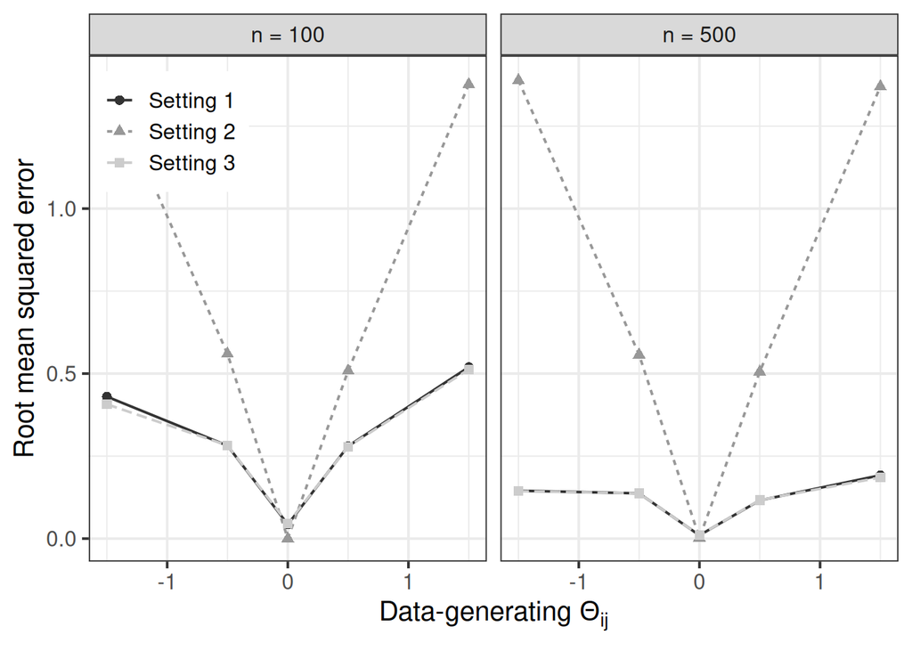

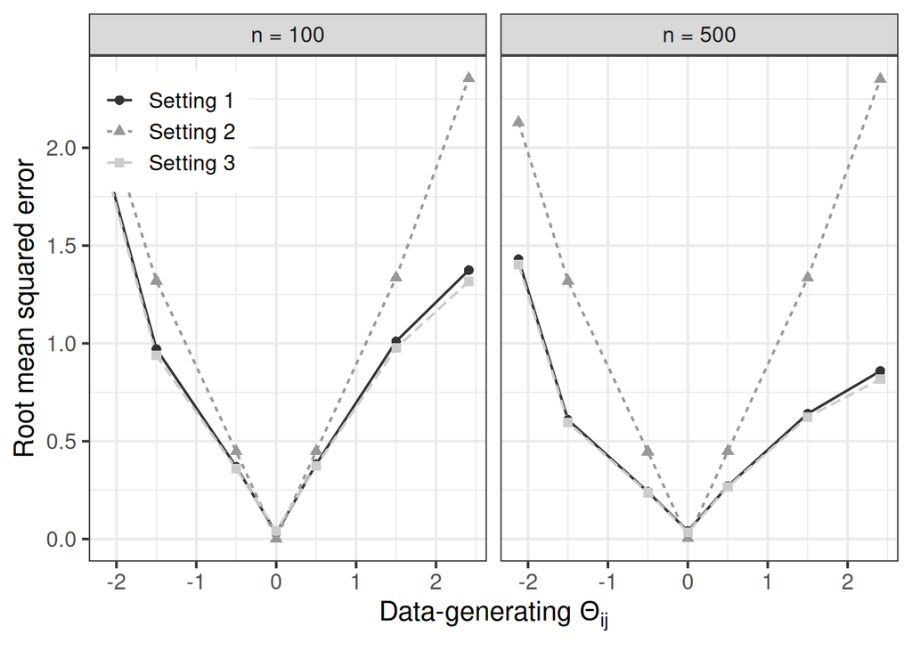

```r
for (i in 1:length(kseq)) {

  myplot <- filter(sim_summary, !(truth %in% diagvals), k==kseq[i]) |>
  ggplot(aes(x=truth, y=root_mse, col=Setting, lty=Setting, pch=Setting)) +
    geom_line() +
    geom_point() +
    facet_wrap(~ n, labeller = labeller(n = function(x) paste0("n = ", x))) +
    theme_bw(base_size = 15) +
    theme(legend.position = c(0.1, 0.85), legend.title=element_blank()) +
    scale_color_grey() +
    xlab(expression("Data-generating " * Theta[ij])) +
    ylab("Root mean squared error")
  print(myplot)

  fname <- paste0("sim_priorsettings_erdosrenyi_rootmse_nodiag_k", kseq[i], ".pdf")
  if (save2pdf) ggsave(fname, plot = myplot)
}
```

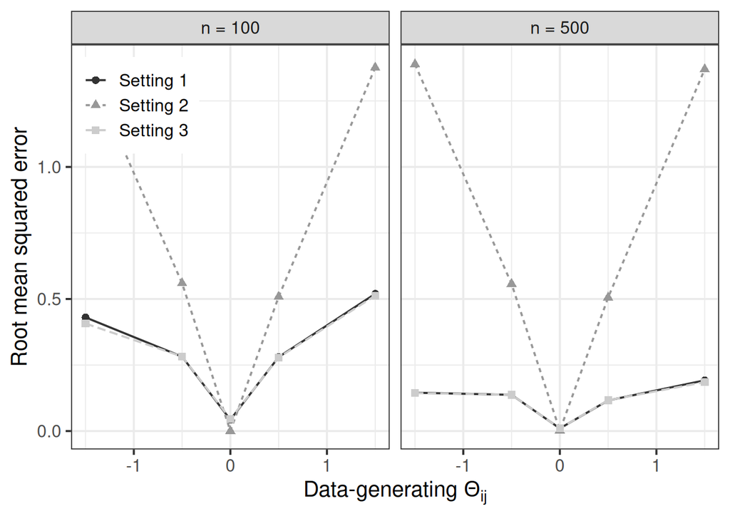

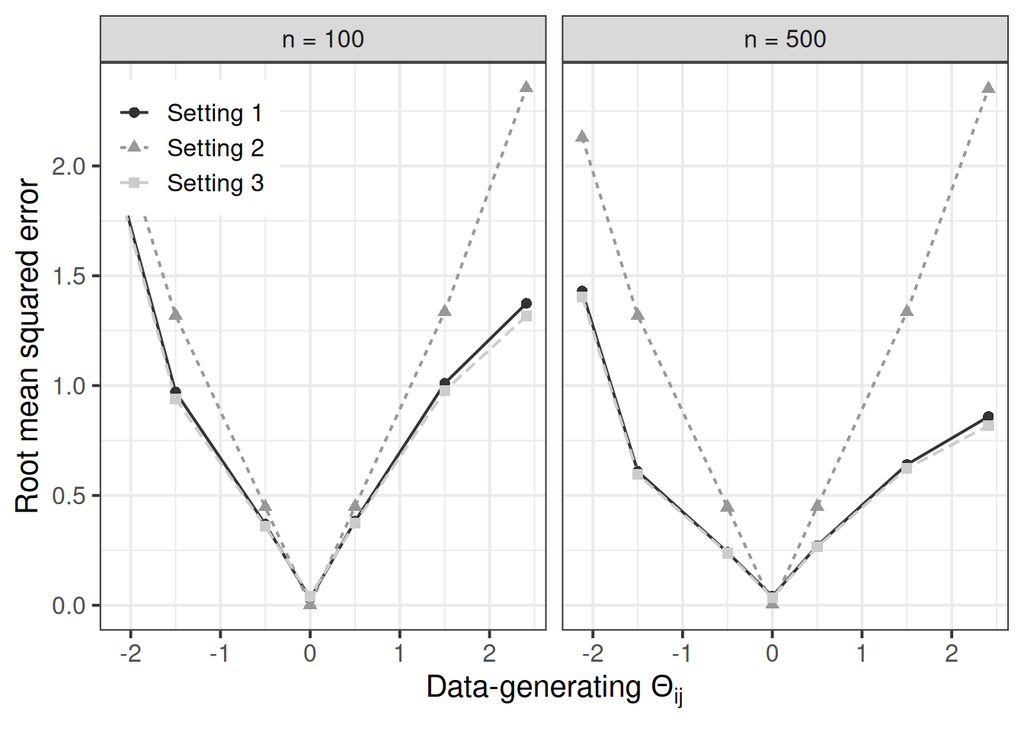

```r
for (i in 1:length(kseq)) {

  myplot <- filter(sim_summary, k==kseq[i]) |>
  ggplot(aes(x=truth, y=root_mse, col=Setting, lty=Setting, pch=Setting)) +
    geom_line() +
    geom_point() +
    facet_wrap(~ n, labeller = labeller(n = function(x) paste0("n = ", x))) +
    theme_bw(base_size = 15) +
    theme(legend.position = c(0.1, 0.85), legend.title=element_blank()) +
    scale_color_grey() +
    xlab(expression("Data-generating " * Theta[ij])) +
    ylab("Root mean squared error")
  print(myplot)

  fname <- paste0("sim_priorsettings_erdosrenyi_rootmse_k", kseq[i], ".pdf")
  if (save2pdf) ggsave(fname, plot = myplot)
}
```

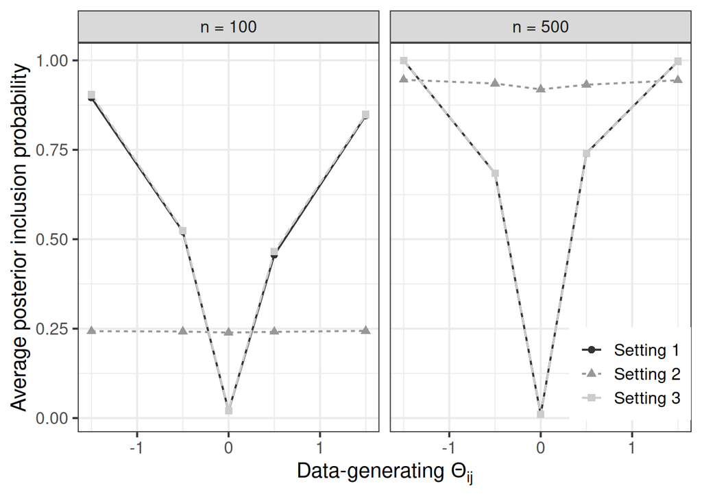

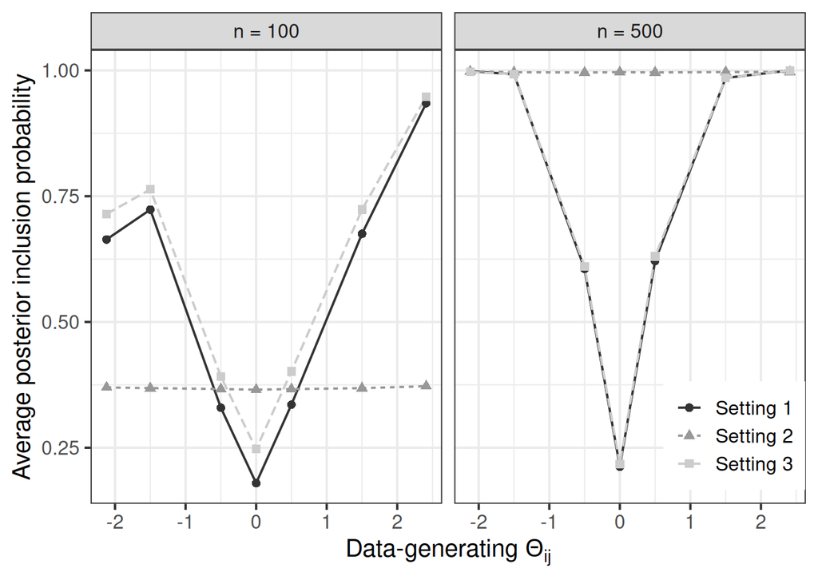

```r
for (i in 1:length(kseq)) {

  myplot <- filter(sim_summary, !(truth %in% diagvals), k==kseq[i]) |>
  ggplot(aes(x=truth, y=pp, col=Setting, lty=Setting, pch=Setting)) +
    geom_line() +
    geom_point() +
    facet_wrap(~ n, labeller = labeller(n = function(x) paste0("n = ", x))) +
    theme_bw(base_size = 15) +
    theme(legend.position = c(0.9, 0.15), legend.title=element_blank()) +
    scale_color_grey() +
    xlab(expression("Data-generating " * Theta[ij])) +
    ylab("Average posterior inclusion probability")
  print(myplot)

  fname <- paste0("sim_priorsettings_erdosrenyi_pp_k", kseq[i], ".pdf")
  if (save2pdf) ggsave(fname, plot = myplot)
}
```

# Block-diagonal graph

## Run simulations

```r
sims1 <- sims2 <- sims3 <- vector("list", length(kseq))
names(sims1) <- names(sims2) <- names(sims3) <- names(kseq)
diagvals <- vector("list", length(kseq))
for (i in 1:length(kseq)) {
  ksel <- kseq[i]  # number of variables
  cat("Simulations for k =", ksel)

  # Data-generating precision matrix
  block_size <- 5
  num_blocks <- ksel / block_size
  B <- matrix(0.5, nrow = block_size, ncol = block_size)
  diag(B) <- 1
  Theta <- kronecker(diag(num_blocks), B)
  Sigma <- solve(Theta)
  diagvals[[i]] <- unique(diag(Theta))

  # Set prior distribution under each setting
  pars_sel <- filter(priorpars, setting == "Setting 1", k == ksel)
  priorModel <- modelbbprior(pars_sel$edge_prob_succ, pars_sel$edge_prob_fail)
  priorDiag <- exponentialprior(lambda = pars_sel$lambda)
  priorCoef <- normalidprior(pars_sel$var.slab)
  sims1[[i]] <- run_simulations(n=nseq, nsims=nsims, Theta=Theta, Sigma=solve(Theta), priorCoef=priorCoef, priorDiag=priorDiag, priorModel=priorModel)

  pars_sel <- filter(priorpars, setting == "Setting 2", k == ksel)
  priorModel <- modelbbprior(pars_sel$edge_prob_succ, pars_sel$edge_prob_fail)
  priorDiag <- exponentialprior(lambda = pars_sel$lambda)
  priorCoef <- normalidprior(pars_sel$var.slab)
  sims2[[i]] <- run_simulations(n=nseq, nsims=nsims, Theta=Theta, Sigma=solve(Theta), priorCoef=priorCoef, priorDiag=priorDiag, priorModel=priorModel)

  pars_sel <- filter(priorpars, setting == "Setting 3", k == ksel)
  priorModel <- modelbbprior(pars_sel$edge_prob_succ, pars_sel$edge_prob_fail)
  priorDiag <- exponentialprior(lambda = pars_sel$lambda)
  priorCoef <- normalidprior(pars_sel$var.slab)
  sims3[[i]] <- run_simulations(n=nseq, nsims=nsims, Theta=Theta, Sigma=solve(Theta), priorCoef=priorCoef, priorDiag=priorDiag, priorModel=priorModel)

  cat("\n")
}
```

```
## Simulations for k = 50........................................................................................................................
## Simulations for k = 100........................................................................................................................
```

```r
diagvals <- unique(unlist(diagvals))
```

We summarize the results across all simulations. For each prior parameter setting and $k= \mbox{dim}(\Theta)$, and each value of the data-generating $\Theta_{ij}$, we report the mean squared estimation error in the Bayesian model averaging estimate $E(\Theta_{ij} \mid y)$, the average marginal posterior edge inclusion probability $P(\Theta_{ij} \neq 0 \mid y)$, and the average BMA estimate.

```r
sim_summary <- summarize_simulations(kseq=kseq, sims1=sims1, sims2=sims2, sims3=sims3)
sim_summary
```

```
##      Setting   k root_mse   n truth    pp mean_estimate count
## 1  Setting 1  50    0.005 100   0.0 0.003        0.0000  1125
## 2  Setting 1  50    0.484 100   0.5 0.075        0.0189   100
## 3  Setting 1  50    0.358 100   1.0 1.000        0.6561    50
## 4  Setting 1  50    0.003 500   0.0 0.012        0.0000  1125
## 5  Setting 1  50    0.051 500   0.5 1.000        0.4807   100
## 6  Setting 1  50    0.061 500   1.0 1.000        0.9954    50
## 7  Setting 2  50    0.000 100   0.0 0.097        0.0000  1125
## 8  Setting 2  50    0.500 100   0.5 0.097        0.0000   100
## 9  Setting 2  50    0.390 100   1.0 1.000        0.6212    50
## 10 Setting 2  50    0.000 500   0.0 0.306        0.0000  1125
## 11 Setting 2  50    0.500 500   0.5 0.320        0.0003   100
## 12 Setting 2  50    0.400 500   1.0 1.000        0.6023    50
## 13 Setting 3  50    0.006 100   0.0 0.004        0.0000  1125
## 14 Setting 3  50    0.480 100   0.5 0.093        0.0248   100
```

[output cut: 22 more lines]

## Plots

We first display the root mean square error, and subsequently the average posterior inclusion probability.

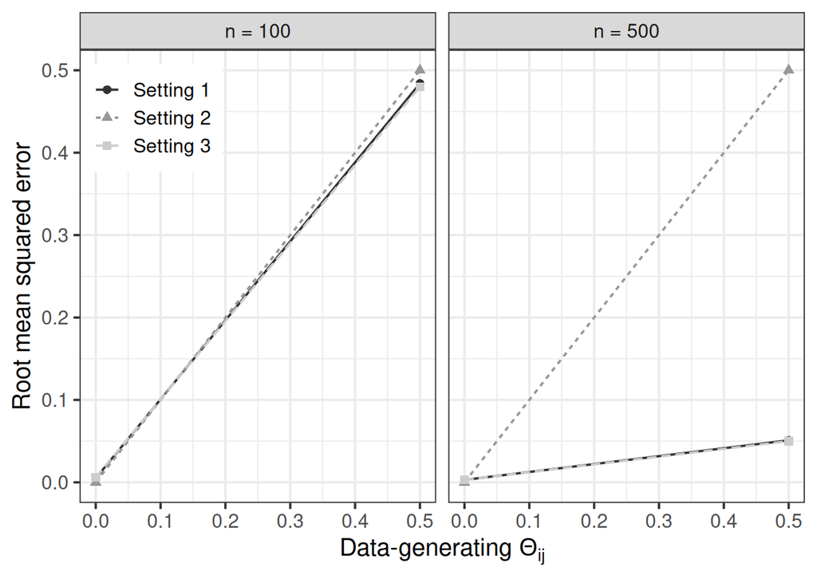

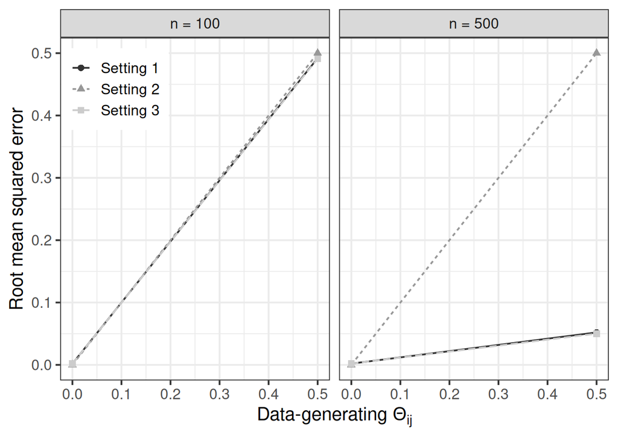

```r
for (i in 1:length(kseq)) {

  myplot <- filter(sim_summary, !(truth %in% diagvals), k==kseq[i]) |>
  ggplot(aes(x=truth, y=root_mse, col=Setting, lty=Setting, pch=Setting)) +
    geom_line() +
    geom_point() +
    facet_wrap(~ n, labeller = labeller(n = function(x) paste0("n = ", x))) +
    theme_bw(base_size = 15) +
    theme(legend.position = c(0.1, 0.85), legend.title=element_blank()) +
    scale_color_grey() +
    xlab(expression("Data-generating " * Theta[ij])) +
    ylab("Root mean squared error")
  print(myplot)

  fname <- paste0("sim_priorsettings_block_rootmse_nodiag_k", kseq[i], ".pdf")
  if (save2pdf) ggsave(fname, plot = myplot)
}
```

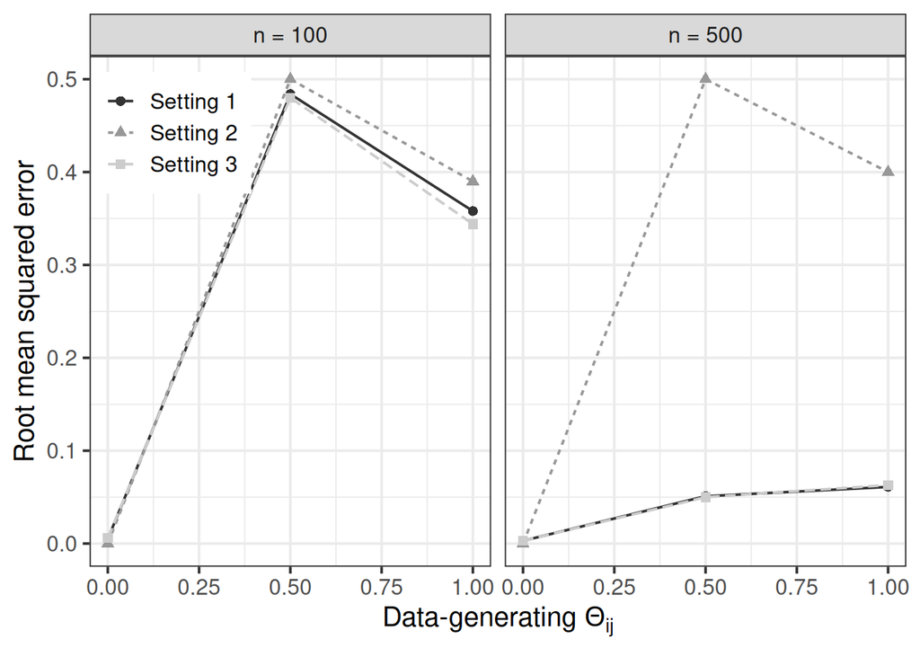

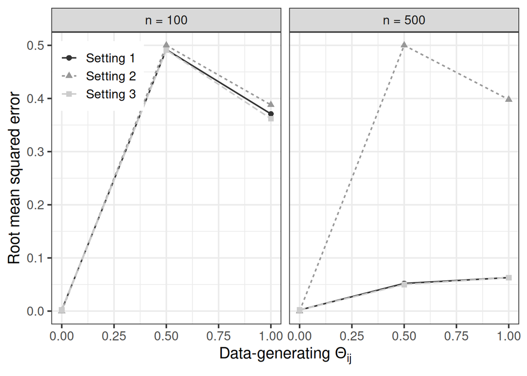

```r
for (i in 1:length(kseq)) {

  myplot <- filter(sim_summary, k==kseq[i]) |>
  ggplot(aes(x=truth, y=root_mse, col=Setting, lty=Setting, pch=Setting)) +
    geom_line() +
    geom_point() +
    facet_wrap(~ n, labeller = labeller(n = function(x) paste0("n = ", x))) +
    theme_bw(base_size = 15) +
    theme(legend.position = c(0.1, 0.85), legend.title=element_blank()) +
    scale_color_grey() +
    xlab(expression("Data-generating " * Theta[ij])) +
    ylab("Root mean squared error")
  print(myplot)

  fname <- paste0("sim_priorsettings_block_rootmse_k", kseq[i], ".pdf")
  if (save2pdf) ggsave(fname, plot = myplot)
}
```

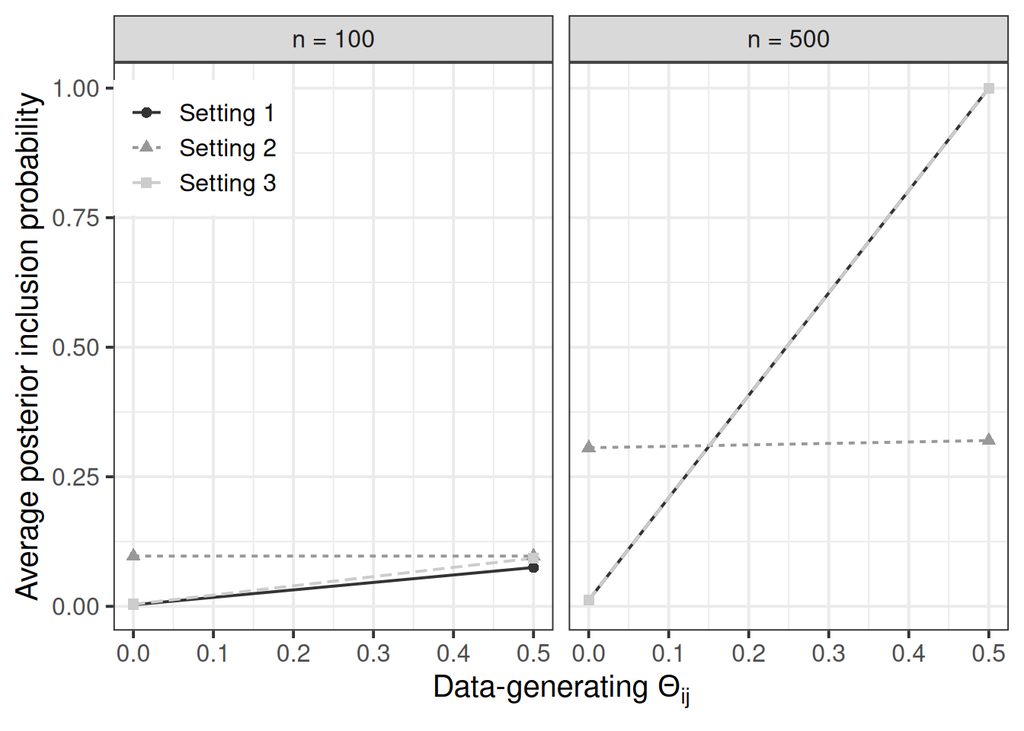

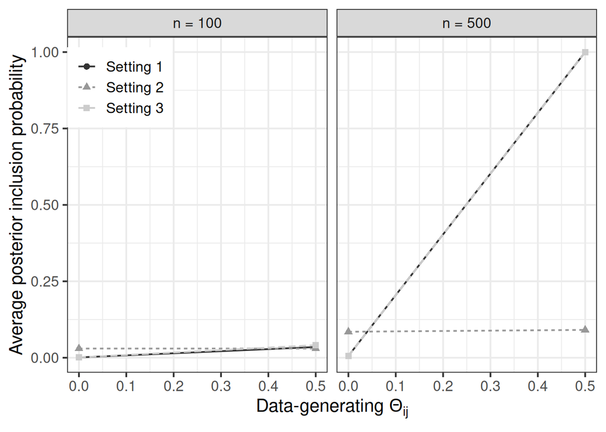

```r
for (i in 1:length(kseq)) {

  myplot <- filter(sim_summary, !(truth %in% diagvals), k==kseq[i]) |>
  ggplot(aes(x=truth, y=pp, col=Setting, lty=Setting, pch=Setting)) +
    geom_line() +
    geom_point() +
    facet_wrap(~ n, labeller = labeller(n = function(x) paste0("n = ", x))) +
    theme_bw(base_size = 15) +
    theme(legend.position = c(0.1, 0.85), legend.title=element_blank()) +
    scale_color_grey() +
    xlab(expression("Data-generating " * Theta[ij])) +
    ylab("Average posterior inclusion probability")
  print(myplot)

  fname <- paste0("sim_priorsettings_block_pp_k", kseq[i], ".pdf")
  if (save2pdf) ggsave(fname, plot = myplot)
}
```